# Module 2: R and Tidyverse Foundations

## Overview

In this module, we will cover:

1. The pipe operator (`%>%` and `|>`)
2. Six core dplyr verbs: `filter`, `select`, `mutate`, `arrange`, `summarize`, `group_by`
3. Recoding variables with `case_when`
4. Tidy data and reshaping with `pivot_longer`/`pivot_wider`
5. Visualization with ggplot2
6. Linear regression in R and the broom package
7. Running many regressions with `nest_by`

## The Tidyverse Ecosystem

[figure not shown]

The tidyverse is an ecosystem of R packages for data science, originally conceived by Hadley Wickham.

## Our Dataset

We use NHANES data from the training set:

```r
nhData <- NHData.train %>%
  select(BMXBMI, LBXGLU, RIDAGEYR, male, female,
         black, mexican, other_hispanic, other_eth, white,
         SDDSRVYR, LBXBPB, LBXBCD, INDFMPIR) %>%
  mutate(PID = row_number())
```

```r
nhData %>% sample_n(5) %>%
  select(PID, BMXBMI, LBXGLU, RIDAGEYR, male, black, white) %>%
  kable() %>% kable_styling(font_size = 9)
```

| PID | BMXBMI | LBXGLU | RIDAGEYR | male | black | white |
| --- | --- | --- | --- | --- | --- | --- |
| 20661 | 16.28 | NA | 7 | 0 | 0 | 1 |
| 12245 | 32.47 | NA | 13 | 0 | 0 | 1 |
| 16945 | 23.20 | 84.5 | 74 | 0 | 0 | 0 |
| 6179 | 24.71 | 111.8 | 85 | 1 | 0 | 1 |
| 14853 | 22.97 | NA | 17 | 1 | 0 | 0 |

## The Pipe Operator

The pipe `%>%` passes the output of one function as the first argument of the next:

```
x %>% f(y)   is equivalent to   f(x, y)
```

Base R also has a native pipe: `|>`

```r
# Without pipe
head(nhData, n = 3) %>% select(PID, BMXBMI, RIDAGEYR, male)
```

```
##   PID BMXBMI RIDAGEYR male
## 1   1  14.90        2    0
## 2   2  24.90       77    1
## 3   3  17.63       10    0
```

```r
# With pipe
nhData %>% head(n = 3) %>% select(PID, BMXBMI, RIDAGEYR, male)
```

```
##   PID BMXBMI RIDAGEYR male
## 1   1  14.90        2    0
## 2   2  24.90       77    1
## 3   3  17.63       10    0
```

## Why Pipe?

Pipes make code more readable by expressing operations left-to-right:

```r
# Nested (hard to read)
head(arrange(filter(nhData, male == 1), -BMXBMI), 5)

# Piped (easy to read)
nhData %>%
  filter(male == 1) %>%
  arrange(-BMXBMI) %>%
  head(5)
```

## dplyr: Six Core Verbs

| Verb | Purpose |
| --- | --- |
| `filter()` | Select rows by conditions |
| `select()` | Choose columns |
| `mutate()` | Create or modify columns |
| `arrange()` | Sort rows |
| `summarize()` | Collapse to summary statistics |
| `group_by()` | Partition data into groups |

## filter(): Select Rows

```r
# Filter to males only
nhData %>%
  filter(male == 1) %>%
  select(PID, BMXBMI, LBXGLU, RIDAGEYR, male) %>%
  head(3) %>%
  kable() %>% kable_styling(font_size = 9)
```

| PID | BMXBMI | LBXGLU | RIDAGEYR | male |
| --- | --- | --- | --- | --- |
| 2 | 24.9 | 83.7 | 77 | 1 |
| 4 | NA | NA | 1 | 1 |
| 5 | 29.1 | 99.9 | 49 | 1 |

## filter(): Multiple Conditions

```r
# Males with glucose >= 126 (diabetic range)
nhData %>%
  filter(male == 1, LBXGLU >= 126) %>%
  select(PID, BMXBMI, LBXGLU, RIDAGEYR, male) %>%
  head(5) %>%
  kable() %>% kable_styling(font_size = 9)
```

| PID | BMXBMI | LBXGLU | RIDAGEYR | male |
| --- | --- | --- | --- | --- |
| 29 | 36.94 | 142.1 | 62 | 1 |
| 211 | 31.30 | 133.7 | 76 | 1 |
| 266 | 29.51 | 165.6 | 82 | 1 |
| 272 | 22.36 | 221.2 | 56 | 1 |
| 695 | 26.10 | 166.1 | 59 | 1 |

## select(): Choose Columns

```r
# Select specific columns
nhData %>% select(male, BMXBMI) %>% head(5)

# Remove columns
nhData %>% select(-c(PID, SDDSRVYR)) %>% head(5)

# Select by name pattern
nhData %>% select(starts_with("LB")) %>% head(5)
```

Other helpers: `ends_with()`, `contains()`, `matches()`, `one_of()`

## select(): Example Output

```r
nhData %>%
  select(starts_with("LB")) %>%
  head(5) %>%
  kable() %>% kable_styling(font_size = 9)
```

| LBXGLU | LBXBPB | LBXBCD |
| --- | --- | --- |
| NA | NA | NA |
| 83.7 | 5.0 | 0.2 |
| NA | 2.2 | 0.2 |
| NA | 9.2 | 0.2 |
| 99.9 | 1.6 | 0.4 |

## Combining filter and select

```r
nhData %>%
  filter(male == 1, LBXGLU > 100) %>%
  select(BMXBMI, LBXGLU) %>%
  head(5) %>%
  kable() %>% kable_styling()
```

| BMXBMI | LBXGLU |
| --- | --- |
| 36.94 | 142.1 |
| 29.74 | 105.9 |
| 29.28 | 106.6 |
| 18.43 | 103.6 |
| 30.67 | 102.9 |

## mutate(): Create New Columns

```r
nhData %>%
  mutate(
    obese = BMXBMI >= 30,
    t2d = LBXGLU >= 126
  ) %>%
  select(BMXBMI, obese, LBXGLU, t2d) %>%
  head(5) %>%
  kable() %>% kable_styling()
```

| BMXBMI | obese | LBXGLU | t2d |
| --- | --- | --- | --- |
| 14.90 | FALSE | NA | NA |
| 24.90 | FALSE | 83.7 | FALSE |
| 17.63 | FALSE | NA | NA |
| NA | NA | NA | NA |
| 29.10 | FALSE | 99.9 | FALSE |

## case_when(): Recode Variables

`case_when` works like a switch statement inside `mutate`:

```r
nhData <- nhData %>%
  mutate(
    gender = case_when(
      male == 1 ~ "Male",
      female == 1 ~ "Female"
    ),
    ethnicity = case_when(
      white == 1 ~ "White",
      black == 1 ~ "Black",
      mexican == 1 ~ "Mexican American",
      other_hispanic == 1 ~ "Other Hispanic",
      other_eth == 1 ~ "Other"
    )
  )
```

## case_when(): Age Groups

```r
nhData <- nhData %>%
  mutate(
    age_group = case_when(
      RIDAGEYR < 18 ~ "[0,18)",
      RIDAGEYR < 30 ~ "[18,30)",
      RIDAGEYR < 60 ~ "[30,60)",
      RIDAGEYR >= 60 ~ "[60+)"
    )
  )

nhData %>%
  count(age_group) %>%
  kable() %>% kable_styling()
```

| age_group | n |
| --- | --- |
| [0,18) | 9563 |
| [18,30) | 3039 |
| [30,60) | 4696 |
| [60+) | 3706 |

## arrange(): Sort Rows

```r
nhData %>%
  select(BMXBMI, LBXGLU, gender) %>%
  arrange(-LBXGLU) %>%
  head(5) %>%
  kable() %>% kable_styling()
```

| BMXBMI | LBXGLU | gender |
| --- | --- | --- |
| 24.51 | 686.2 | Male |
| 29.46 | 587.3 | Male |
| 27.55 | 581.6 | Female |
| 31.16 | 445.0 | Male |
| 30.82 | 442.7 | Male |

## summarize(): Collapse to Summary

```r
nhData %>%
  summarize(
    n = n(),
    mean_bmi = mean(BMXBMI, na.rm = TRUE),
    sd_bmi = sd(BMXBMI, na.rm = TRUE),
    mean_glucose = mean(LBXGLU, na.rm = TRUE)
  ) %>%
  kable(digits = 2) %>% kable_styling()
```

| n | mean_bmi | sd_bmi | mean_glucose |
| --- | --- | --- | --- |
| 21004 | 24.79 | 7.03 | 100.51 |

## group_by(): Partition Data

```r
nhData %>%
  group_by(gender) %>%
  summarize(
    n = n(),
    mean_bmi = mean(BMXBMI, na.rm = TRUE),
    mean_glucose = mean(LBXGLU, na.rm = TRUE)
  ) %>%
  kable(digits = 2) %>% kable_styling()
```

| gender | n | mean_bmi | mean_glucose |
| --- | --- | --- | --- |
| Female | 10790 | 25.21 | 97.91 |
| Male | 10214 | 24.36 | 103.29 |

## group_by(): Multiple Groups

```r
nhData %>%
  mutate(obese = BMXBMI >= 30) %>%
  group_by(gender, obese) %>%
  summarize(
    n = n(),
    mean_glucose = mean(LBXGLU, na.rm = TRUE),
    .groups = "drop"
  ) %>%
  kable(digits = 2) %>% kable_styling()
```

| gender | obese | n | mean_glucose |
| --- | --- | --- | --- |
| Female | FALSE | 6909 | 94.93 |
| Female | TRUE | 2085 | 105.23 |
| Female | NA | 1796 | 102.56 |
| Male | FALSE | 7028 | 100.74 |
| Male | TRUE | 1450 | 110.94 |
| Male | NA | 1736 | 117.89 |

## Tidy Data

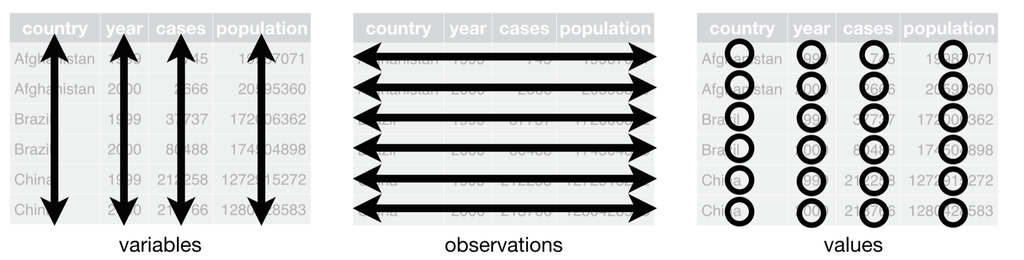

**Tidy data principles** (Hadley Wickham, inspired by E.F. Codd):

1. Each variable forms a column
2. Each observation forms a row
3. Each type of observational unit forms a table

## Is NHANES Tidy?

```r
nhData %>%
  select(PID, BMXBMI, LBXGLU, gender, ethnicity) %>%
  sample_n(5) %>%
  kable() %>% kable_styling()
```

| PID | BMXBMI | LBXGLU | gender | ethnicity |
| --- | --- | --- | --- | --- |
| 3354 | 21.73 | 84.1 | Male | Other Hispanic |
| 2269 | 17.39 | NA | Male | Mexican American |
| 2482 | 24.67 | NA | Female | Mexican American |
| 10296 | 26.45 | 91.3 | Male | Black |
| 21001 | NA | NA | Male | White |

**Yes** — each row is one participant’s measurements.

## pivot_longer(): Wide to Long

```r
nhData_long <- nhData %>%
  pivot_longer(
    cols = c(BMXBMI, LBXGLU),
    names_to = "measurement",
    values_to = "value"
  )

nhData_long %>%
  select(PID, measurement, value, gender) %>%
  head(6) %>%
  kable() %>% kable_styling()
```

| PID | measurement | value | gender |
| --- | --- | --- | --- |
| 1 | BMXBMI | 14.90 | Female |
| 1 | LBXGLU | NA | Female |
| 2 | BMXBMI | 24.90 | Male |
| 2 | LBXGLU | 83.70 | Male |
| 3 | BMXBMI | 17.63 | Female |
| 3 | LBXGLU | NA | Female |

## pivot_wider(): Long to Wide

```r
nhData_wide <- nhData_long %>%
  select(PID, measurement, value) %>%
  pivot_wider(names_from = measurement, values_from = value)

nhData_wide %>%
  head(5) %>%
  kable() %>% kable_styling()
```

| PID | BMXBMI | LBXGLU |
| --- | --- | --- |
| 1 | 14.90 | NA |
| 2 | 24.90 | 83.7 |
| 3 | 17.63 | NA |
| 4 | NA | NA |
| 5 | 29.10 | 99.9 |

## ggplot2: Grammar of Graphics

**Components of a ggplot:**

- `data`: the data frame
- `aes()`: aesthetic mappings (x, y, color, size, shape)
- `geom_*()`: geometric objects (points, bars, lines)
- `facet_*()`: faceting for small multiples
- `theme_*()`: appearance

```r
ggplot(data, aes(x = var1, y = var2)) +
  geom_point()
```

## Histogram

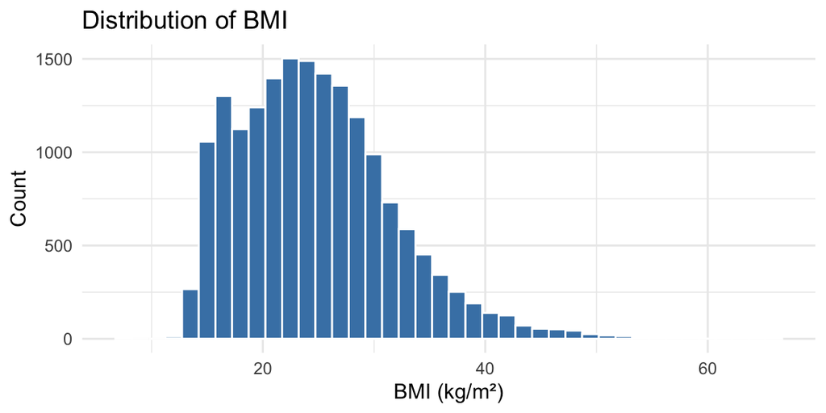

```r
ggplot(nhData, aes(x = BMXBMI)) +
  geom_histogram(bins = 40, fill = "steelblue", color = "white") +
  labs(x = "BMI (kg/m²)", y = "Count", title = "Distribution of BMI") +
  theme_minimal()
```

## Histogram with Facets

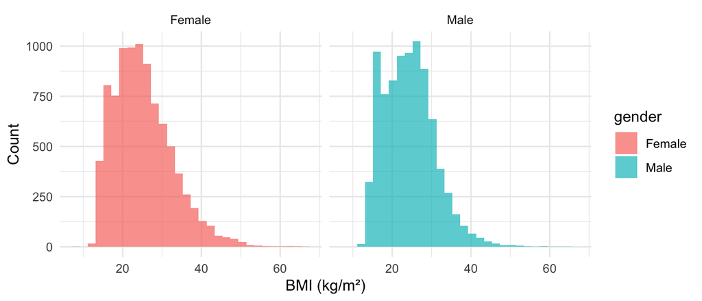

```r
ggplot(nhData, aes(x = BMXBMI, fill = gender)) +
  geom_histogram(bins = 30, alpha = 0.7) +
  facet_wrap(~gender) +
  labs(x = "BMI (kg/m²)", y = "Count") +
  theme_minimal()
```

## Boxplot

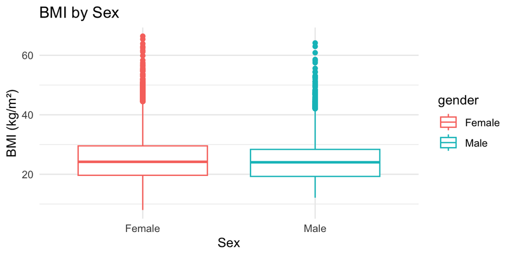

```r
ggplot(nhData, aes(x = gender, y = BMXBMI, color = gender)) +
  geom_boxplot() +
  labs(x = "Sex", y = "BMI (kg/m²)", title = "BMI by Sex") +
  theme_minimal()
```

## Boxplot with Facets by Ethnicity

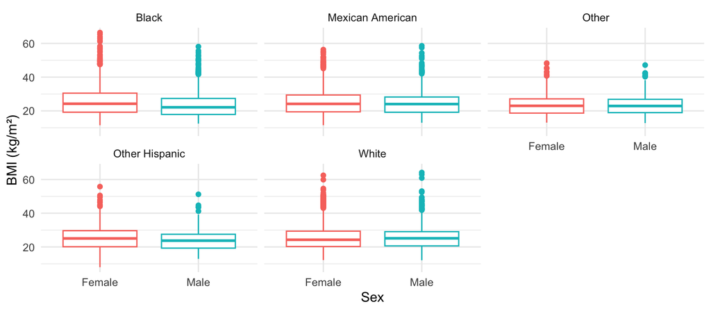

```r
ggplot(nhData, aes(x = gender, y = BMXBMI, color = gender)) +
  geom_boxplot() +
  facet_wrap(~ethnicity) +
  labs(x = "Sex", y = "BMI (kg/m²)") +
  theme_minimal() +
  theme(legend.position = "none")
```

## Scatterplot

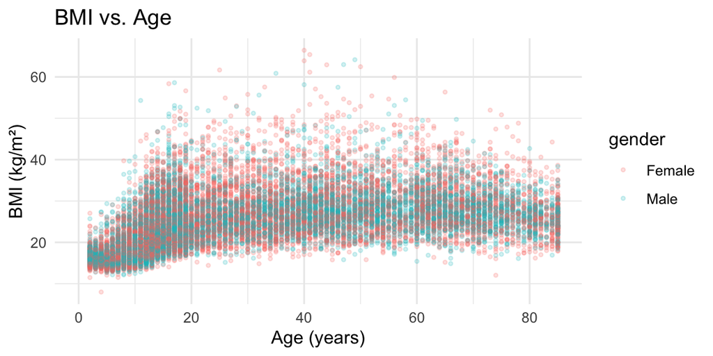

```r
ggplot(nhData, aes(x = RIDAGEYR, y = BMXBMI, color = gender)) +
  geom_point(alpha = 0.2, size = 0.8) +
  labs(x = "Age (years)", y = "BMI (kg/m²)", title = "BMI vs. Age") +
  theme_minimal()
```

## Scatterplot with Facets

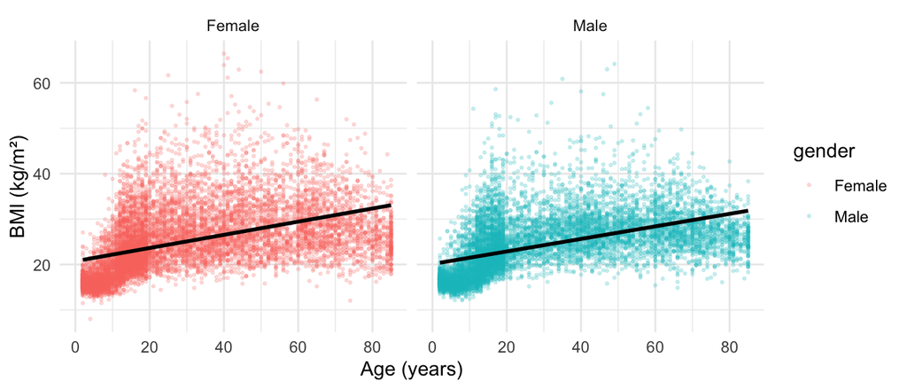

```r
ggplot(nhData, aes(x = RIDAGEYR, y = BMXBMI, color = gender)) +
  geom_point(alpha = 0.2, size = 0.5) +
  facet_wrap(~gender) +
  geom_smooth(method = "lm", se = FALSE, color = "black") +
  labs(x = "Age (years)", y = "BMI (kg/m²)") +
  theme_minimal()
```

## Linear Regression in R

Model the relationship: \(y = \alpha + \sum_{i=1}^{M} \beta_i x_i\)

```r
fit <- lm(LBXGLU ~ BMXBMI + RIDAGEYR + male + black + mexican +
            other_hispanic + other_eth,
          data = nhData)
```

Three levels of output:

1. **Model level**: \(R^2\), residual standard error
2. **Term level**: coefficient estimates, p-values
3. **Observation level**: predictions, residuals

## Model Summary

```r
summary(fit)
```

```
##
## Call:
## lm(formula = LBXGLU ~ BMXBMI + RIDAGEYR + male + black + mexican +
##     other_hispanic + other_eth, data = nhData)
##
## Residuals:
##    Min     1Q Median     3Q    Max
## -77.67 -11.76  -4.21   3.49 592.88
##
## Coefficients:
##                Estimate Std. Error t value Pr(>|t|)
## (Intercept)    64.46384    1.80388  35.736  < 2e-16 ***
## BMXBMI          0.57673    0.06243   9.237  < 2e-16 ***
## RIDAGEYR        0.39515    0.01863  21.212  < 2e-16 ***
## male            5.62365    0.76229   7.377 1.82e-13 ***
## black           1.98181    1.02949   1.925  0.05427 .
## mexican         5.83894    0.94913   6.152 8.12e-10 ***
## other_hispanic  5.56316    1.84842   3.010  0.00263 **
## other_eth       5.29182    2.15850   2.452  0.01425 *
## ---
## Signif. codes:  0 '***' 0.001 '**' 0.01 '*' 0.05 '.' 0.1 ' ' 1
##
## Residual standard error: 30.25 on 6324 degrees of freedom
##   (14672 observations deleted due to missingness)
## Multiple R-squared:  0.1068, Adjusted R-squared:  0.1058
## F-statistic:   108 on 7 and 6324 DF,  p-value: < 2.2e-16
```

## Interpreting the Coefficients

- `BMXBMI`: change in glucose per 1 kg/m² increase in BMI
- `RIDAGEYR`: change in glucose per 1 year increase in age
- `male`: difference in glucose for males vs. females (reference)
- `black`, `mexican`, etc.: difference vs. white (reference group)

Reference categories: **female** for sex, **white** for race/ethnicity.

## The broom Package

broom tidies model output into data frames:

| Function | Returns | Description |
| --- | --- | --- |
| `glance()` | 1-row tibble | Model-level summary (\(R^2\), AIC) |
| `tidy()` | Per-term tibble | Coefficients, p-values per variable |
| `augment()` | Per-observation tibble | Predictions, residuals |

## glance(): Model-Level Summary

```r
glance(fit) %>%
  select(r.squared, adj.r.squared, sigma, p.value) %>%
  kable(digits = 4) %>% kable_styling()
```

| r.squared | adj.r.squared | sigma | p.value |
| --- | --- | --- | --- |
| 0.1068 | 0.1058 | 30.2453 | 0 |

## tidy(): Term-Level Summary

```r
tidy(fit) %>%
  select(term, estimate, std.error, p.value) %>%
  kable(digits = 4) %>% kable_styling(font_size = 9)
```

| term | estimate | std.error | p.value |
| --- | --- | --- | --- |
| (Intercept) | 64.4638 | 1.8039 | 0.0000 |
| BMXBMI | 0.5767 | 0.0624 | 0.0000 |
| RIDAGEYR | 0.3952 | 0.0186 | 0.0000 |
| male | 5.6237 | 0.7623 | 0.0000 |
| black | 1.9818 | 1.0295 | 0.0543 |
| mexican | 5.8389 | 0.9491 | 0.0000 |
| other_hispanic | 5.5632 | 1.8484 | 0.0026 |
| other_eth | 5.2918 | 2.1585 | 0.0142 |

## augment(): Observation-Level

```r
augment(fit) %>%
  select(LBXGLU, .fitted, .resid) %>%
  head(5) %>%
  kable(digits = 2) %>% kable_styling()
```

| LBXGLU | .fitted | .resid |
| --- | --- | --- |
| 83.7 | 114.87 | -31.17 |
| 99.9 | 106.23 | -6.33 |
| 85.6 | 106.71 | -21.11 |
| 84.2 | 84.17 | 0.03 |
| 89.8 | 106.90 | -17.10 |

## Running Many Regressions with nest_by

**Goal**: Predict BMI and glucose as a function of age, sex, ethnicity — stratified by survey year.

**Step 1**: Make data long

```r
nhData_long <- nhData %>%
  pivot_longer(cols = c(LBXGLU, BMXBMI),
               names_to = "outcome",
               values_to = "value")
```

## Step 2: nest_by and Fit Models

```r
regressions <- nhData_long %>%
  nest_by(outcome, SDDSRVYR) %>%
  mutate(fit = list(lm(value ~ RIDAGEYR + male + black + mexican +
                         other_hispanic + other_eth,
                       data = data))) %>%
  select(-data)
```

```r
regressions
```

```
## # A tibble: 4 × 3
## # Rowwise:  outcome, SDDSRVYR
##   outcome SDDSRVYR fit
##   <chr>      <dbl> <list>
## 1 BMXBMI         1 <lm>
## 2 BMXBMI         2 <lm>
## 3 LBXGLU         1 <lm>
## 4 LBXGLU         2 <lm>
```

## Step 3: Extract R² from Each Model

```r
regressions %>%
  summarise(glance(fit)) %>%
  select(outcome, SDDSRVYR, r.squared) %>%
  arrange(outcome, SDDSRVYR) %>%
  kable(digits = 3) %>% kable_styling()
```

| outcome | SDDSRVYR | r.squared |
| --- | --- | --- |
| BMXBMI | 1 | 0.228 |
| BMXBMI | 2 | 0.233 |
| LBXGLU | 1 | 0.103 |
| LBXGLU | 2 | 0.090 |

## Step 4: Extract Coefficients from Each Model

```r
regressions %>%
  summarise(tidy(fit)) %>%
  select(outcome, SDDSRVYR, term, estimate, p.value) %>%
  head(10) %>%
  kable(digits = 3) %>% kable_styling(font_size = 9)
```

| outcome | SDDSRVYR | term | estimate | p.value |
| --- | --- | --- | --- | --- |
| BMXBMI | 1 | (Intercept) | 20.075 | 0.000 |
| BMXBMI | 1 | RIDAGEYR | 0.145 | 0.000 |
| BMXBMI | 1 | male | -1.063 | 0.000 |
| BMXBMI | 1 | black | 1.453 | 0.000 |
| BMXBMI | 1 | mexican | 1.209 | 0.000 |
| BMXBMI | 1 | other_hispanic | 0.854 | 0.005 |
| BMXBMI | 1 | other_eth | 0.818 | 0.028 |
| BMXBMI | 2 | (Intercept) | 19.948 | 0.000 |
| BMXBMI | 2 | RIDAGEYR | 0.149 | 0.000 |
| BMXBMI | 2 | male | -0.632 | 0.000 |

## Putting It All Together

The tidyverse workflow for ExWAS:

1. **Load and clean** data with dplyr (`mutate`, `filter`, `select`)
2. **Reshape** data with tidyr (`pivot_longer`)
3. **Visualize** data with ggplot2
4. **Model** with `lm()` or `svyglm()`
5. **Tidy** results with broom (`tidy`, `glance`)
6. **Scale** analyses with `nest_by` + `map`

## Summary

- The **pipe** operator makes code readable and composable
- **dplyr** provides 6 core verbs for data manipulation
- **case_when** enables flexible variable recoding
- **pivot_longer/wider** reshapes data between wide and long formats
- **ggplot2** creates publication-quality visualizations
- **broom** tidies model output for downstream analysis
- **nest_by** scales regressions across groups

## What’s Next?

**Module 3: Statistical Foundations for ExWAS**

- Survey sampling and svydesign/svyglm
- Log transformation and standardization
- Multiple testing correction
- Confounding and DAGs